# GitHubRintro

Libby Mojica

2023-01-18

#Course information https://github.com/Data-Sci-Intro-2023/Week-1-Intro/blob/main/lessons/intro-basics.md Video: https://www.youtube.com/watch?v=l3-xEn1KQxY&t=929s

```r
source("setup.R")
```

[output not shown]

# 6.1 Load penguins dataset

```r
data("penguins")

penguins
```

```
## # A tibble: 344 × 8
##    species island    bill_length_mm bill_depth_mm flipper_…¹ body_…² sex    year
##    <fct>   <fct>              <dbl>         <dbl>      <int>   <int> <fct> <int>
##  1 Adelie  Torgersen           39.1          18.7        181    3750 male   2007
##  2 Adelie  Torgersen           39.5          17.4        186    3800 fema…  2007
##  3 Adelie  Torgersen           40.3          18          195    3250 fema…  2007
##  4 Adelie  Torgersen           NA            NA           NA      NA <NA>   2007
##  5 Adelie  Torgersen           36.7          19.3        193    3450 fema…  2007
##  6 Adelie  Torgersen           39.3          20.6        190    3650 male   2007
##  7 Adelie  Torgersen           38.9          17.8        181    3625 fema…  2007
##  8 Adelie  Torgersen           39.2          19.6        195    4675 male   2007
##  9 Adelie  Torgersen           34.1          18.1        193    3475 <NA>   2007
## 10 Adelie  Torgersen           42            20.2        190    4250 <NA>   2007
## # … with 334 more rows, and abbreviated variable names ¹flipper_length_mm,
## #   ²body_mass_g
```

# 6.2 Learning data types in R

vector - character, 1 dimensional list - 1 dimensional matrix - 2 dimensional

```r
class(penguins)
```

```
## [1] "tbl_df"     "tbl"        "data.frame"
```

```r
str(penguins)
```

```
## tibble [344 × 8] (S3: tbl_df/tbl/data.frame)
##  $ species          : Factor w/ 3 levels "Adelie","Chinstrap",..: 1 1 1 1 1 1 1 1 1 1 ...
##  $ island           : Factor w/ 3 levels "Biscoe","Dream",..: 3 3 3 3 3 3 3 3 3 3 ...
##  $ bill_length_mm   : num [1:344] 39.1 39.5 40.3 NA 36.7 39.3 38.9 39.2 34.1 42 ...
##  $ bill_depth_mm    : num [1:344] 18.7 17.4 18 NA 19.3 20.6 17.8 19.6 18.1 20.2 ...
##  $ flipper_length_mm: int [1:344] 181 186 195 NA 193 190 181 195 193 190 ...
##  $ body_mass_g      : int [1:344] 3750 3800 3250 NA 3450 3650 3625 4675 3475 4250 ...
##  $ sex              : Factor w/ 2 levels "female","male": 2 1 1 NA 1 2 1 2 NA NA ...
##  $ year             : int [1:344] 2007 2007 2007 2007 2007 2007 2007 2007 2007 2007 ...
```

```r
class(penguins$species)
```

```
## [1] "factor"
```

Data type: Lists

```r
myList <- list("apple", 1993, FALSE, penguins)
str(myList)
```

```
## List of 4
##  $ : chr "apple"
##  $ : num 1993
##  $ : logi FALSE
##  $ : tibble [344 × 8] (S3: tbl_df/tbl/data.frame)
##   ..$ species          : Factor w/ 3 levels "Adelie","Chinstrap",..: 1 1 1 1 1 1 1 1 1 1 ...
##   ..$ island           : Factor w/ 3 levels "Biscoe","Dream",..: 3 3 3 3 3 3 3 3 3 3 ...
##   ..$ bill_length_mm   : num [1:344] 39.1 39.5 40.3 NA 36.7 39.3 38.9 39.2 34.1 42 ...
##   ..$ bill_depth_mm    : num [1:344] 18.7 17.4 18 NA 19.3 20.6 17.8 19.6 18.1 20.2 ...
##   ..$ flipper_length_mm: int [1:344] 181 186 195 NA 193 190 181 195 193 190 ...
##   ..$ body_mass_g      : int [1:344] 3750 3800 3250 NA 3450 3650 3625 4675 3475 4250 ...
##   ..$ sex              : Factor w/ 2 levels "female","male": 2 1 1 NA 1 2 1 2 NA NA ...
##   ..$ year             : int [1:344] 2007 2007 2007 2007 2007 2007 2007 2007 2007 2007 ...
```

```r
names(myList) <- c("fruit", "year", "logic", "data")
names(myList)
```

```
## [1] "fruit" "year"  "logic" "data"
```

# 6.3 Learning Indexing

for lists we use double brackets pulls first thing in list

```r
myList[[1]]
```

```
## [1] "apple"
```

index vectors, single bracket for brackets pulls second item in list

```r
myVector <- c("apple", "banana", "pear")
myVector[2]
```

```
## [1] "banana"
```

Index data frames examples

```r
# dataframe[row(s), then columns()]
# code will pull rows 1 to 5 on column 2
penguins[1:5, 2]
```

```
## # A tibble: 5 × 1
##   island
##   <fct>
## 1 Torgersen
## 2 Torgersen
## 3 Torgersen
## 4 Torgersen
## 5 Torgersen
```

```r
penguins[1:5, "island"]
```

```
## # A tibble: 5 × 1
##   island
##   <fct>
## 1 Torgersen
## 2 Torgersen
## 3 Torgersen
## 4 Torgersen
## 5 Torgersen
```

```r
penguins[1, 1:5]
```

```
## # A tibble: 1 × 5
##   species island    bill_length_mm bill_depth_mm flipper_length_mm
##   <fct>   <fct>              <dbl>         <dbl>             <int>
## 1 Adelie  Torgersen           39.1          18.7               181
```

```r
penguins[1:5, c("species","sex")]
```

```
## # A tibble: 5 × 2
##   species sex
##   <fct>   <fct>
## 1 Adelie  male
## 2 Adelie  female
## 3 Adelie  female
## 4 Adelie  <NA>
## 5 Adelie  female
```

```r
penguins[penguins$sex=='female',]
```

```
## # A tibble: 176 × 8
##    species island    bill_length_mm bill_depth_mm flipper_…¹ body_…² sex    year
##    <fct>   <fct>              <dbl>         <dbl>      <int>   <int> <fct> <int>
##  1 Adelie  Torgersen           39.5          17.4        186    3800 fema…  2007
##  2 Adelie  Torgersen           40.3          18          195    3250 fema…  2007
##  3 <NA>    <NA>                NA            NA           NA      NA <NA>     NA
##  4 Adelie  Torgersen           36.7          19.3        193    3450 fema…  2007
##  5 Adelie  Torgersen           38.9          17.8        181    3625 fema…  2007
##  6 <NA>    <NA>                NA            NA           NA      NA <NA>     NA
##  7 <NA>    <NA>                NA            NA           NA      NA <NA>     NA
##  8 <NA>    <NA>                NA            NA           NA      NA <NA>     NA
##  9 <NA>    <NA>                NA            NA           NA      NA <NA>     NA
## 10 Adelie  Torgersen           41.1          17.6        182    3200 fema…  2007
## # … with 166 more rows, and abbreviated variable names ¹flipper_length_mm,
## #   ²body_mass_g
```

## 6.3.1 Exercises

1. Why don’t the following lines of code work? Tweak each one so the code runs

```r
myList["fruit"]
```

```
## $fruit
## [1] "apple"
```

```r
penguins$flipper_length_mm
```

```
##   [1] 181 186 195  NA 193 190 181 195 193 190 186 180 182 191 198 185 195 197
##  [19] 184 194 174 180 189 185 180 187 183 187 172 180 178 178 188 184 195 196
##  [37] 190 180 181 184 182 195 186 196 185 190 182 179 190 191 186 188 190 200
##  [55] 187 191 186 193 181 194 185 195 185 192 184 192 195 188 190 198 190 190
##  [73] 196 197 190 195 191 184 187 195 189 196 187 193 191 194 190 189 189 190
##  [91] 202 205 185 186 187 208 190 196 178 192 192 203 183 190 193 184 199 190
## [109] 181 197 198 191 193 197 191 196 188 199 189 189 187 198 176 202 186 199
## [127] 191 195 191 210 190 197 193 199 187 190 191 200 185 193 193 187 188 190
## [145] 192 185 190 184 195 193 187 201 211 230 210 218 215 210 211 219 209 215
## [163] 214 216 214 213 210 217 210 221 209 222 218 215 213 215 215 215 216 215
## [181] 210 220 222 209 207 230 220 220 213 219 208 208 208 225 210 216 222 217
## [199] 210 225 213 215 210 220 210 225 217 220 208 220 208 224 208 221 214 231
## [217] 219 230 214 229 220 223 216 221 221 217 216 230 209 220 215 223 212 221
## [235] 212 224 212 228 218 218 212 230 218 228 212 224 214 226 216 222 203 225
## [253] 219 228 215 228 216 215 210 219 208 209 216 229 213 230 217 230 217 222
## [271] 214  NA 215 222 212 213 192 196 193 188 197 198 178 197 195 198 193 194
## [289] 185 201 190 201 197 181 190 195 181 191 187 193 195 197 200 200 191 205
## [307] 187 201 187 203 195 199 195 210 192 205 210 187 196 196 196 201 190 212
## [325] 187 198 199 201 193 203 187 197 191 203 202 194 206 189 195 207 202 193
## [343] 210 198
```

```r
penguins[penguins$island=='Dream',]
```

```
## # A tibble: 124 × 8
##    species island bill_length_mm bill_depth_mm flipper_len…¹ body_…² sex    year
##    <fct>   <fct>           <dbl>         <dbl>         <int>   <int> <fct> <int>
##  1 Adelie  Dream            39.5          16.7           178    3250 fema…  2007
##  2 Adelie  Dream            37.2          18.1           178    3900 male   2007
##  3 Adelie  Dream            39.5          17.8           188    3300 fema…  2007
##  4 Adelie  Dream            40.9          18.9           184    3900 male   2007
##  5 Adelie  Dream            36.4          17             195    3325 fema…  2007
##  6 Adelie  Dream            39.2          21.1           196    4150 male   2007
##  7 Adelie  Dream            38.8          20             190    3950 male   2007
##  8 Adelie  Dream            42.2          18.5           180    3550 fema…  2007
##  9 Adelie  Dream            37.6          19.3           181    3300 fema…  2007
## 10 Adelie  Dream            39.8          19.1           184    4650 male   2007
## # … with 114 more rows, and abbreviated variable names ¹flipper_length_mm,
## #   ²body_mass_g
```

2. How many species are in the penguins dataset? What islands were the data collected for? (Note: the unique() function might help)

```r
#There are 3 penguin species
unique(penguins$species)
```

```
## [1] Adelie    Gentoo    Chinstrap
## Levels: Adelie Chinstrap Gentoo
```

3.Use indexing to create a new data frame that has only 3 columns: species, island and flipper length columns, and subset all rows for just the ‘Dream’ island.

```r
newpenguins <- penguins[penguins$island=='Dream', c("species", "island", "flipper_length_mm")]
newpenguins
```

```
## # A tibble: 124 × 3
##    species island flipper_length_mm
##    <fct>   <fct>              <int>
##  1 Adelie  Dream                178
##  2 Adelie  Dream                178
##  3 Adelie  Dream                188
##  4 Adelie  Dream                184
##  5 Adelie  Dream                195
##  6 Adelie  Dream                196
##  7 Adelie  Dream                190
##  8 Adelie  Dream                180
##  9 Adelie  Dream                181
## 10 Adelie  Dream                184
## # … with 114 more rows
```

4.Use indexing and the mean() function to find the average flipper length for the Adelie species on Dream island. (Note: explore the mean() function and how to deal with NA values).

```r
penguins %>%
  filter(species == "Adelie", island == "Dream")%>%
  summarise (mean = mean(penguins$flipper_length_mm, na.rm = TRUE))
```

```
## # A tibble: 1 × 1
##    mean
##   <dbl>
## 1  201.
```

# 6.4 Learning the dplyr package

Subset rows with filter() Select columns with select() Create new variables with mutate() Converts to to a grouped table group_by() Pipes express a sequence of operations

## 6.3.2 Exercises

1.Reorder the variables in penguins so that year is the first column followed by the rest (Hint: look into the use of everything()).

```r
penguins [,c(8,1,2,3,4,5,6,7)]
```

```
## # A tibble: 344 × 8
##     year species island    bill_length_mm bill_depth_mm flipper_…¹ body_…² sex
##    <int> <fct>   <fct>              <dbl>         <dbl>      <int>   <int> <fct>
##  1  2007 Adelie  Torgersen           39.1          18.7        181    3750 male
##  2  2007 Adelie  Torgersen           39.5          17.4        186    3800 fema…
##  3  2007 Adelie  Torgersen           40.3          18          195    3250 fema…
##  4  2007 Adelie  Torgersen           NA            NA           NA      NA <NA>
##  5  2007 Adelie  Torgersen           36.7          19.3        193    3450 fema…
##  6  2007 Adelie  Torgersen           39.3          20.6        190    3650 male
##  7  2007 Adelie  Torgersen           38.9          17.8        181    3625 fema…
##  8  2007 Adelie  Torgersen           39.2          19.6        195    4675 male
##  9  2007 Adelie  Torgersen           34.1          18.1        193    3475 <NA>
## 10  2007 Adelie  Torgersen           42            20.2        190    4250 <NA>
## # … with 334 more rows, and abbreviated variable names ¹flipper_length_mm,
## #   ²body_mass_g
```

2.Create a new column called ‘size_group’ where individuals with body mass greater than the overall average are called ‘large’ and those smaller are called ‘small’.

```r
penguins %>%
  mutate(size_group = if_else(body_mass_g < mean(body_mass_g, na.rm = TRUE),
                              paste0("small"), paste0("large") ))
```

```
## # A tibble: 344 × 9
##    species island    bill_length_mm bill_d…¹ flipp…² body_…³ sex    year size_…⁴
##    <fct>   <fct>              <dbl>    <dbl>   <int>   <int> <fct> <int> <chr>
##  1 Adelie  Torgersen           39.1     18.7     181    3750 male   2007 small
##  2 Adelie  Torgersen           39.5     17.4     186    3800 fema…  2007 small
##  3 Adelie  Torgersen           40.3     18       195    3250 fema…  2007 small
##  4 Adelie  Torgersen           NA       NA        NA      NA <NA>   2007 <NA>
##  5 Adelie  Torgersen           36.7     19.3     193    3450 fema…  2007 small
##  6 Adelie  Torgersen           39.3     20.6     190    3650 male   2007 small
##  7 Adelie  Torgersen           38.9     17.8     181    3625 fema…  2007 small
##  8 Adelie  Torgersen           39.2     19.6     195    4675 male   2007 large
##  9 Adelie  Torgersen           34.1     18.1     193    3475 <NA>   2007 small
## 10 Adelie  Torgersen           42       20.2     190    4250 <NA>   2007 large
## # … with 334 more rows, and abbreviated variable names ¹bill_depth_mm,
## #   ²flipper_length_mm, ³body_mass_g, ⁴size_group
```

3. Find out which year for each species were individuals on average the largest according to body mass.

```r
penguins%>%
  group_by(year, species) %>%
  summarise(mean_mass = mean(body_mass_g, na.rm = TRUE)) %>%
  arrange(species, desc(mean_mass))
```

```
## # A tibble: 9 × 3
## # Groups:   year [3]
##    year species   mean_mass
##   <int> <fct>         <dbl>
## 1  2008 Adelie        3742
## 2  2007 Adelie        3696.
## 3  2009 Adelie        3665.
## 4  2008 Chinstrap     3800
## 5  2009 Chinstrap     3725
## 6  2007 Chinstrap     3694.
## 7  2009 Gentoo        5141.
## 8  2007 Gentoo        5071.
## 9  2008 Gentoo        5020.
```

4. You want to filter data for years that are not in a vector of given years, but this code doesn’t work. Tweak it so that it does.

```r
penguins %>%
  filter(year != c(2008, 2009))
```

```
## # A tibble: 227 × 8
##    species island    bill_length_mm bill_depth_mm flipper_…¹ body_…² sex    year
##    <fct>   <fct>              <dbl>         <dbl>      <int>   <int> <fct> <int>
##  1 Adelie  Torgersen           39.1          18.7        181    3750 male   2007
##  2 Adelie  Torgersen           39.5          17.4        186    3800 fema…  2007
##  3 Adelie  Torgersen           40.3          18          195    3250 fema…  2007
##  4 Adelie  Torgersen           NA            NA           NA      NA <NA>   2007
##  5 Adelie  Torgersen           36.7          19.3        193    3450 fema…  2007
##  6 Adelie  Torgersen           39.3          20.6        190    3650 male   2007
##  7 Adelie  Torgersen           38.9          17.8        181    3625 fema…  2007
##  8 Adelie  Torgersen           39.2          19.6        195    4675 male   2007
##  9 Adelie  Torgersen           34.1          18.1        193    3475 <NA>   2007
## 10 Adelie  Torgersen           42            20.2        190    4250 <NA>   2007
## # … with 217 more rows, and abbreviated variable names ¹flipper_length_mm,
## #   ²body_mass_g
```

## 7.1 Exercises

1. Make a barplot showing the average flipper length for each species.

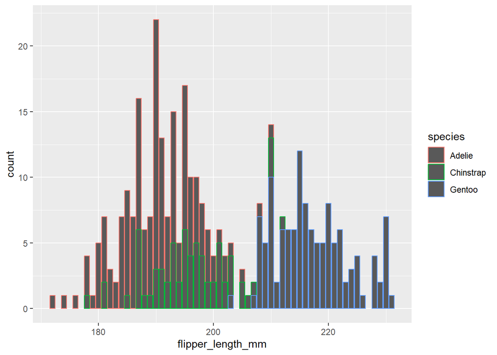

```r
penguins %>%
  ggplot +
  geom_bar( mapping = aes(x = flipper_length_mm, color = species))
```

2. Make a scatter plot of bill length compared to bill depth but only for observations on the Dream island.

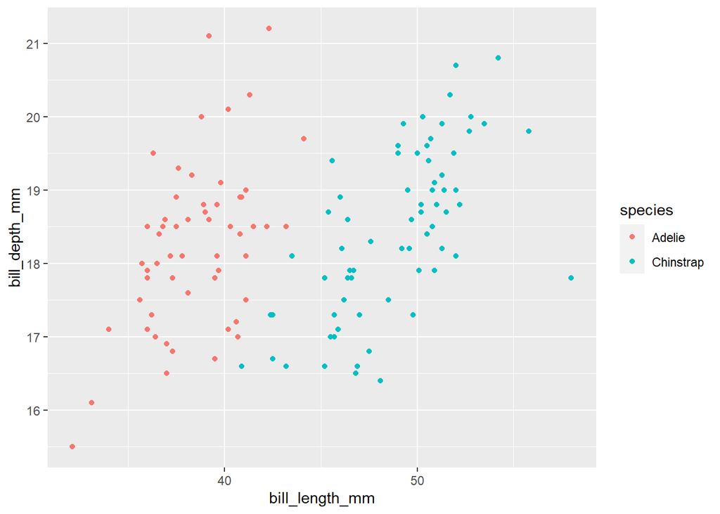

```r
penguins %>%
  filter(island == "Dream") %>%
  ggplot +
  geom_point(mapping = aes(bill_length_mm, bill_depth_mm, color = species))
```